# MAST30027: Expectation-Maximization (EM) Algorithm for Mixture Models

Week 7 - Solutions

**Objectives of the Tutorial/Lab** By the end of this tutorial, you should be able to:

- Simulate data from finite Poisson mixture models.
- Derive the E-step and M-step of the EM algorithm for a Poisson mixture.
- Implement and interpret the EM algorithm for a Poisson mixture model.

## Question 1

Simulate 100 samples from the following mixture model. For $i=1, \ldots, 100$,

$$Z_i \sim \text{categorical }(0.8, 0.2),$$

$$X_i | Z_i = 1 \sim \text{Pois}(\lambda_1=2) \text{ and } X_i | Z_i = 2 \sim \text{Pois}(\lambda_2=8).$$

The Poisson distribution has probability mass function
$$f(x; \lambda) = \frac{\lambda^x e^{-\lambda}}{x!}.$$
Please set a seed using `set.seed(30027)`. Make a histogram of the simulated samples.

**💡 Solution**

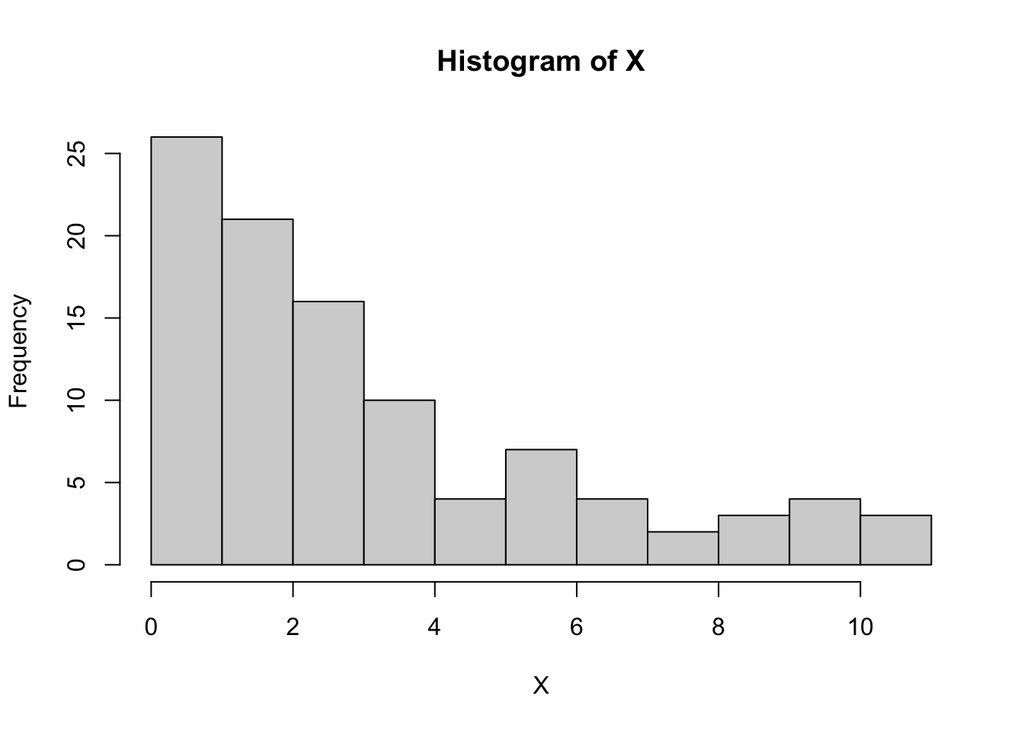

```r
set.seed(30027)
lambda_1   <- 2
lambda_2   <- 8
pi_1 <- 0.8
pi_2 <- 1-pi_1
NUM.SAMPLES <- 100
X <- rep(NA, NUM.SAMPLES)
Z <- rep(NA, NUM.SAMPLES)
for(i in seq_len(NUM.SAMPLES)) {
  Z[i] <- rbinom(1,1, pi_2)
  if(Z[i] == 0) X[i] <- rpois(1, lambda_1)
  else X[i] <- rpois(1, lambda_2)
}
hist(X)
```

```r
mean(Z)
```

```
[1] 0.24
```

```r
mean(X[which(Z==1)])
```

```
[1] 7.708333
```

```r
mean(X[which(Z==0)])
```

```
[1] 2.171053
```

**📈 Plotting it using ggplot2**

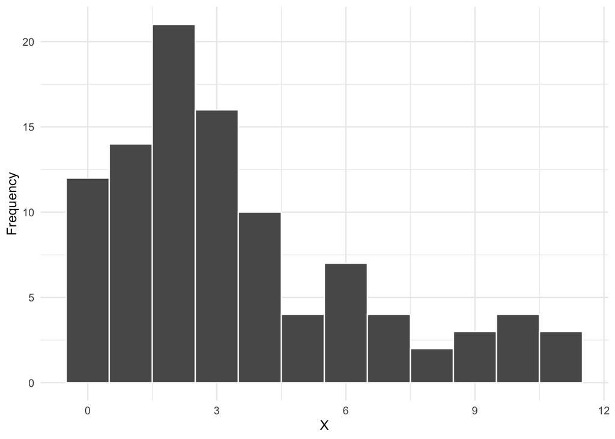

```r
library(ggplot2)
ggplot(data.frame(X=X), aes(X)) +
  geom_histogram(binwidth=1, boundary=-.5, colour="white") +
  labs(x="X", y="Frequency") + theme_minimal()
```

The true proportion of the second component in the simulated data (based on $Z$, the true cluster information) is $0.24$. Sample means of the simulated data from the fist and second components are $2.17$ and $7.7$, respectively.

## Question 2

We pretend that we just observe the simulated samples. We will assume that the observed data follow a mixture of two Poisson distributions. Specifically, for $i=1, \ldots, 100$,

$$Z_i \sim \text{categorical }(\pi_1, 1-\pi_1),$$

$$X_i | Z_i = 1 \sim \text{Poisson}(\lambda_1) \text{ and } X_i | Z_i = 2 \sim \text{Poisson}(\lambda_2).$$

We aim to obtain MLE of parameters $\theta = (\pi_1, \lambda_1, \lambda_2)$ using the EM algorithm.

Let $X = (X_1, \ldots, X_{100})$ and $Z=(Z_1, \ldots, Z_{100})$. Derive the expectation of the complete log-likelihood, $Q(\theta, \theta^0) = E_{Z|X, \theta^0}[\log (P(X,Z|\theta))]$.

**💡 Solution**

Let $n=100$.
$$\begin{aligned}
p(X_1,...X_n,Z_1,...,Z_n|\theta)&=\prod_{i=1}^{n}p(X_i|Z_i,\theta)p(Z_i|\theta)\\
&=\prod_{i=1}^{n}\prod_{k=1}^{2}[p(X_i|Z_i=k,\theta)p(Z_i=k|\theta)]^{I_{(Z_i=k)}}.
\end{aligned}$$

$$\begin{aligned}
\log[p(X_1,...X_n,Z_1,...,Z_n|\theta)]&=\sum_{i=1}^{n}\sum_{i=1}^{2}{I_{(Z_i=k)}[\log p(X_i|Z_i=k,\theta) + \log p(Z_i=k|\theta)]}\\
&=\sum_{i=1}^{n}\Big[I_{(Z_i=1)}[X_i\log \lambda_1-\lambda_1-\log X_i! +\log \pi_1]\\
& \qquad + I_{(Z_i=2)}[X_i\log \lambda_2-\lambda_2-\log X_i! +\log (1-\pi_1)]\Big].
\end{aligned}$$

$$\begin{aligned}
Q(\theta,\theta^0)&=E_{Z|X,\theta^0}[\log p(X_1,...X_n,Z_1,...,Z_n|\theta)]\\
&=\sum_{i=1}^{n}\Big[p(Z_i=1|X,\theta^0)[X_i\log \lambda_1-\lambda_1-\log X_i! +\log \pi_1]\\
&\qquad + p(Z_i=2|X,\theta^0)[X_i\log \lambda_2-\lambda_2-\log X_i! +\log (1-\pi_1)]\Big].
\end{aligned}$$

Derive E-step and M-step of the EM algorithm.

**💡 Solution**

**E-step**: $\theta^0 = (\pi_1^0, \lambda_1^0, \lambda_2^0)$
$$\begin{aligned}
p(Z_i=1|X,\theta^0)&=\frac{p(Z_i=1, X_i|\theta^0)}{p(X_i|\theta^0)}\\
&=\frac{p(X_i|Z_i=1,\theta^0)p(Z_i=1|\theta^0)}{p(X_i|Z_i=1,\theta^0)p(Z_i=1|\theta^0) + p(X_i|Z_i=2,\theta^0)p(Z_i=2|\theta^0)}\\
&=\frac{\frac{(\lambda_1^0)^{x_i} e^{-\lambda_1^0}}{x_i!}\pi_1^0}{\frac{(\lambda_1^0)^{x_i} e^{-\lambda_1^0}}{x_i!}\pi_1^0 + \frac{(\lambda_2^0)^{x_i}e^{-\lambda_2^0}}{x_i!}(1-\pi_1^0)}.\\
p(Z_i=2|X,\theta^0)&=1-p(Z_i=1|X,\theta^0).
\end{aligned}$$
**M-step:**
$$\begin{aligned}
\frac{\partial Q(\theta,\theta^0)}{\partial \pi_1} &= \sum_{i=1}^{n}\Big[\frac{p(Z_i=1|X,\theta^0)}{\pi_1}-\frac{p(Z_i=2|X,\theta^0)}{1-\pi_1} \Big]\\
&=\frac{(1-\pi_1)[\sum_{i=1}^{n}p(Z_i=1|X,\theta^0)]-\pi_1[\sum_{i=1}^{n}p(Z_i=2|X,\theta^0)]}{\pi_1(1-\pi_1)}=0.
\end{aligned}$$
$$\sum_{i=1}^{n}p(Z_i=1|X,\theta^0)-n\pi_1 = 0,$$
$$\hat{\pi}_1=\frac{\sum_{i=1}^{n}p(Z_i=1|X,\theta^0)}{n}.$$

$$\frac{\partial Q(\theta, \theta^0)}{\partial \lambda_1} = \frac{\sum_{i=1}^{n}p(Z_i=1|X,\theta^0)X_i}{\lambda_1}-\sum_{i=1}^{n}p(Z_i=1|X,\theta^0)=0,$$
$$\hat{\lambda}_1=\frac{\sum_{i=1}^{n}p(Z_i=1|X,\theta^0)X_i}{\sum_{i=1}^{n}p(Z_i=1|X,\theta^0)}.$$

$$\frac{\partial Q(\theta, \theta^0)}{\partial \lambda_2} = \frac{\sum_{i=1}^{n}p(Z_i=2|X,\theta^0)X_i}{\lambda_2}-\sum_{i=1}^{n}p(Z_i=2|X,\theta^0)=0,$$
$$\hat{\lambda}_2=\frac{\sum_{i=1}^{n}p(Z_i=2|X,\theta^0)X_i}{\sum_{i=1}^{n}p(Z_i=2|X,\theta^0)}.$$

Implement the EM algorithm and obtain MLE of the parameters by applying the implemented algorithm to the simulated data. Run the EM algorithm multiple times with different initial values and pick estimators with the highest incomplete log-likelihood. For each run, check that the incomplete log-likelihoods increases at each step by plotting them.

**💡 Solution**

```r
# w.init : initial value for pi
# lambda_init : initial value for lambda
# epsilon : If the incomplete log-likelihood has changed by less than epsilon, EM will stop.
# max.iter : maximum number of EM-iterations
mixture.EM <- function(X, w.init, lambda_init, epsilon=1e-5, max.iter=100) {

  w.curr = w.init
  lambda_curr = lambda_init

  # store incomplete log-likehoods for each iteration
  log_liks = c()

  # compute incomplete log-likehoods using initial values of parameters.
  log_liks = c(log_liks, compute.log.lik(X, w.curr, lambda_curr)$ill)

  # set the change in incomplete log-likelihood with 1
  delta.ll = 1

  # number of iteration
  n.iter = 1

  # If the log-likelihood has changed by less than epsilon, EM will stop.
  while((delta.ll > epsilon) & (n.iter <= max.iter)){

    # run EM step
    EM.out = EM.iter(X, w.curr, lambda_curr)

    # replace the current value with the new parameter estimate
    w.curr = EM.out$w.new
    lambda_curr = EM.out$lambda_new

    # incomplete log-likehoods with new parameter estimate
    log_liks = c(log_liks, compute.log.lik(X, w.curr, lambda_curr)$ill)

    # compute the change in incomplete log-likelihood
    delta.ll = log_liks[length(log_liks)]  - log_liks[length(log_liks)-1]

    # increase the number of iteration
    n.iter = n.iter + 1

  }

  return(list(w.curr=w.curr, lambda_curr=lambda_curr, log_liks=log_liks))

}

EM.iter <- function(X, w.curr, lambda_curr) {

  # E-step: compute E_{Z|X,\theta_0}[I(Z_i = k)]

  # for each sample $X_i$, compute $P(X_i, Z_i=k)$
  prob.x.z = compute.prob.x.z(X, w.curr, lambda_curr)$prob.x.z

  # compute P(Z_i=k | X_i)
  P_ik = prob.x.z / rowSums(prob.x.z)

  # M-step
  w.new = colSums(P_ik)/sum(P_ik)  # sum(P_ik) is equivalent to sample size
  lambda_new = colSums(P_ik*X)/colSums(P_ik)

  return(list(w.new=w.new, lambda_new=lambda_new))
}

# for each sample $X_i$, compute $P(X_i, Z_i=k)$
compute.prob.x.z <- function(X, w.curr, lambda_curr) {

  # for each sample $X_i$, compute $P(X_i, Z_i=k)$. Store these values in the columns of L:
  L = matrix(NA, nrow=length(X), ncol= length(w.curr))
  for(k in seq_len(ncol(L))) {
    L[, k] = dpois(X, lambda_curr[k])*w.curr[k]
}

return(list(prob.x.z=L))
}

# Compute incomplete log-likehoods
compute.log.lik <- function(X, w.curr, lambda_curr) {

  # for each sample $X_i$, compute $P(X_i, Z_i=k)$
  prob.x.z = compute.prob.x.z(X, w.curr, lambda_curr)$prob.x.z

  # incomplete log-likehoods
  ill = sum(log(rowSums(prob.x.z)))

  return(list(ill=ill))
}
```

Run EM algorithm with different initial values and check that the incomplete log-likelihoods increases at each step by plotting them.

```r
EM1 <- mixture.EM(X, w.init=c(0.5,0.5), lambda_init=c(10, 5), epsilon=1e-5, max.iter=100)
ee = EM1
print(paste("Estimate pi = (", round(ee$w.curr[1],2), ",",
round(ee$w.curr[2],2), ")", sep=""))
```

```
[1] "Estimate pi = (0.29,0.71)"
```

```r
print(paste("True pi = (", pi_1, ",", pi_2, ")", sep=""))
```

```
[1] "True pi = (0.8,0.2)"
```

```r
print(paste("Estimate lambda = (", round(ee$lambda_curr[1],2), ",",
round(ee$lambda_curr[2],2), ")", sep=""))
```

```
[1] "Estimate lambda = (7.12,2.05)"
```

```r
print(paste("True lambda = (", lambda_1, ",", lambda_2, ")", sep=""))
```

```
[1] "True lambda = (2,8)"
```

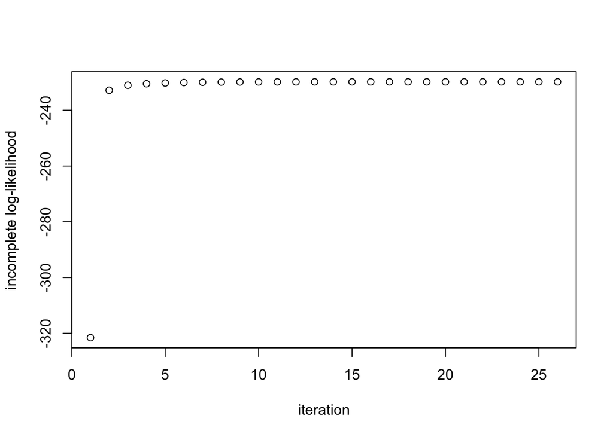

```r
plot(ee$log_liks, ylab='incomplete log-likelihood', xlab='iteration')
```

**📈 Plotting it using ggplot2**

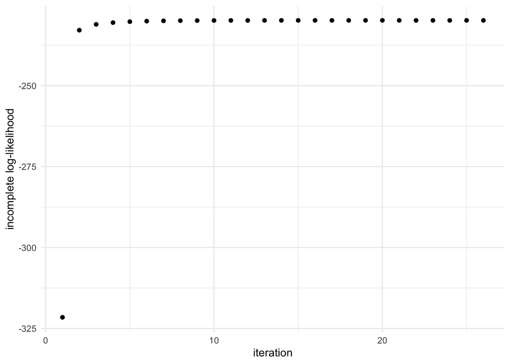

```r
library(ggplot2)
ggplot(data.frame(iteration=seq_along(EM1$log_liks), log_likelihood=EM1$log_liks),
       aes(iteration, log_likelihood)) +
  geom_point() +
  labs(y="incomplete log-likelihood") +
  theme_minimal()
```

```r
EM2 <- mixture.EM(X, w.init=c(0.5,0.5), lambda_init=c(5, 10), epsilon=1e-5, max.iter=100)
ee = EM2
print(paste("Estimate pi = (", round(ee$w.curr[1],2), ",",
round(ee$w.curr[2],2), ")", sep=""))
```

```
[1] "Estimate pi = (0.71,0.29)"
```

```r
print(paste("True pi = (", pi_1, ",", pi_2, ")", sep=""))
```

```
[1] "True pi = (0.8,0.2)"
```

```r
print(paste("Estimate lambda = (", round(ee$lambda_curr[1],2), ",",
round(ee$lambda_curr[2],2), ")", sep=""))
```

```
[1] "Estimate lambda = (2.05,7.12)"
```

```r
print(paste("True lambda = (", lambda_1, ",", lambda_2, ")", sep=""))
```

```
[1] "True lambda = (2,8)"
```

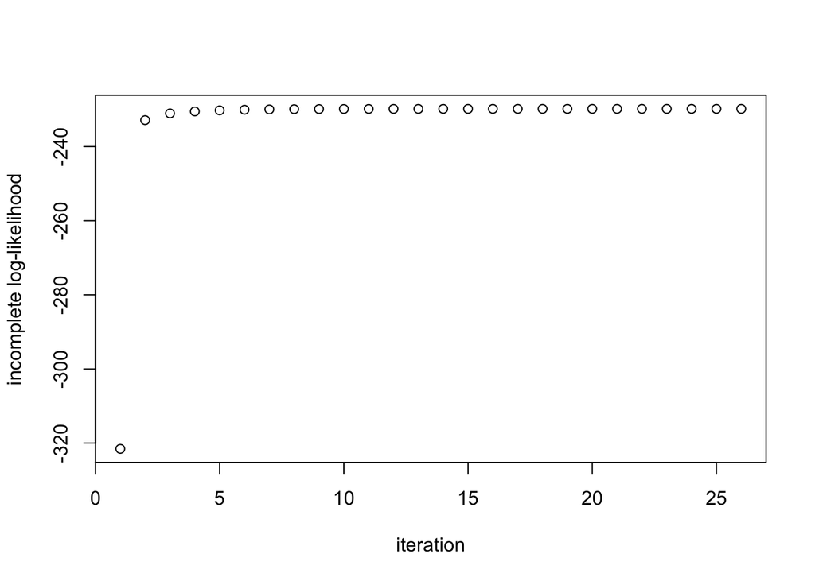

```r
plot(ee$log_liks, ylab='incomplete log-likelihood', xlab='iteration')
```

**📈 Plotting it using ggplot2**

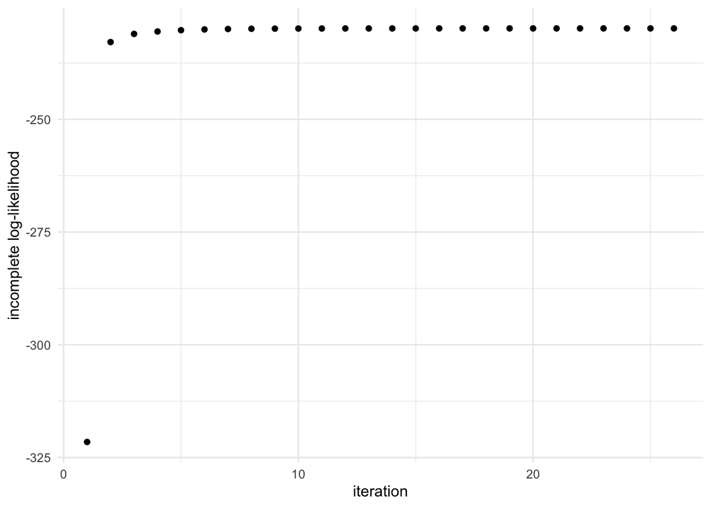

```r
library(ggplot2)
ggplot(data.frame(iteration=seq_along(EM2$log_liks), log_likelihood=EM2$log_liks),
       aes(iteration, log_likelihood)) +
  geom_point() +
  labs(y="incomplete log-likelihood") +
  theme_minimal()
```

```r
EM3 <- mixture.EM(X, w.init=c(0.3,0.7), lambda_init=c(5, 5), epsilon=1e-5, max.iter=100)
ee = EM3
print(paste("Estimate pi = (", round(ee$w.curr[1],2), ",",
round(ee$w.curr[2],2), ")", sep=""))
```

```
[1] "Estimate pi = (0.3,0.7)"
```

```r
print(paste("True pi = (", pi_1, ",", pi_2, ")", sep=""))
```

```
[1] "True pi = (0.8,0.2)"
```

```r
print(paste("Estimate lambda = (", round(ee$lambda_curr[1],2), ",",
round(ee$lambda_curr[2],2), ")", sep=""))
```

```
[1] "Estimate lambda = (3.5,3.5)"
```

```r
print(paste("True lambda = (", lambda_1, ",", lambda_2, ")", sep=""))
```

```
[1] "True lambda = (2,8)"
```

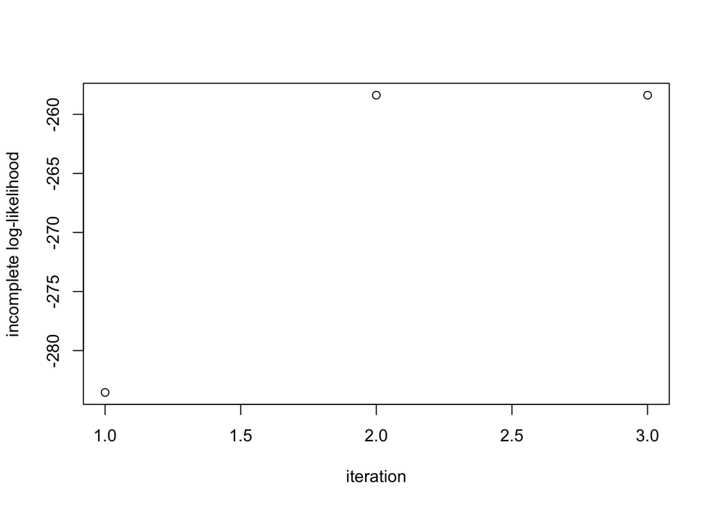

```r
plot(ee$log_liks, ylab='incomplete log-likelihood', xlab='iteration')
```

**📈 Plotting it using ggplot2**

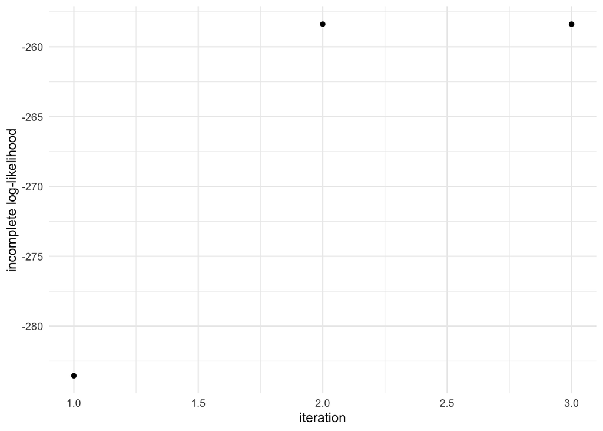

```r
library(ggplot2)
ggplot(data.frame(iteration=seq_along(EM3$log_liks), log_likelihood=EM3$log_liks),
       aes(iteration, log_likelihood)) +
  geom_point() +
  labs(y="incomplete log-likelihood") +
  theme_minimal()
```

Check which estimators have the highest incomplete log-likelihood.

```r
EM1$log_liks[length(EM1$log_liks)]
```

```
[1] -229.834
```

```r
EM2$log_liks[length(EM2$log_liks)]
```

```
[1] -229.834
```

```r
EM3$log_liks[length(EM3$log_liks)]
```

```
[1] -258.3824
```

Estimators from the first two EM runs have (equally) highest incomplete log-likelihoods. You can see that the estimators from the two EM runs are the same if labels for clusters are switched. So it doesn’t matter which estimators we choose. I will choose the estimators from the first EM run - $\hat\pi_1 = 0.29, \hat\lambda_1 = 7.12, \hat\lambda_2 = 2.05$ which are similar to true values of the parameters (once labels for clusters are switched).